# Biostats Lecture 11: Review

## Public Health 783

### Ralph Trane

### University of Wisconsin–Madison<br><br>

### Fall 2019

# Review

Topics covered:

1. Descriptive Statistics

2. Probability and Random Variables

3. Statistical Hypothesis Tests

4. Confidence Intervals

5. Linear Regression

* Important to describe your sample
    - to avoid generalizing when you shouldn't

* Distinguish between categorical and continuous variables
    - when categorical
        - tables: frequency counts, relative frequencies
        - graphs: bar chart prefered

- when continuous
        - tables: mean, sd or median, min, max
        - graphs for one variable: histogram, boxplots
        - graphs for two: scatter plot

* Important to consider if data should be stratified
    - often done if main outcome is categorical

## Take-aways from descriptive statistics

What you absolutely need to know:

* why we need to describe/summarize our data
* when to pick what kind of summary
* when to pick what kind of plot
* how to read boxplots, histograms, and bar charts
* how to create the simple summary statistics using `SAS`
    - `proc means` and `proc freq`
* how to generate and boxplots using `SAS`
    - `proc sort` and then `proc boxplot`

* Probability: the proportion of times an event happens if experiment repeated over and over again

* Random Variable: a variable where the outcome cannot be determined before the experiment

* Distribution:
    - for categorical variable, histogram that gives the probabilities of each outcome
    - for continuous, curve
    - for both, total area must be 1!

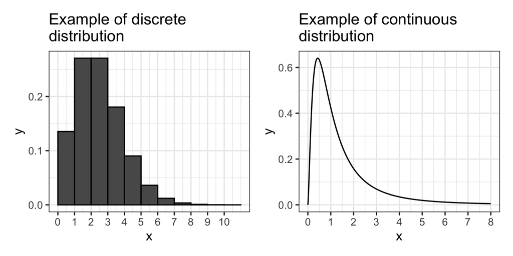

* Important distributions:

- bernoulli
        * discrete
        * binary outcome, one has probability `\(p\)`, the other probability `\(1-p\)`
        * think coin toss, sex, disease status (if disease/healthy)

- binomial
        * discrete
        * a number of bernoulli's added up
        * think number of individuals in a sample with disease

- normal
        * continuous
        * occurs often in nature
        * turns out, averages (if enough samples are included) are normally distributed (Central Limit Theorem)

* Other distributions we have used:

- t-distribution
        * almost normal, and when `\(n\)` large enough, impossible to tell from normal

- `\(\chi^2\)` distribution
        * used for `\(\chi^2\)` test

## Take-aways from Probability and Random Variables

What you absolutely need to know:

* how to interpret a probability
    - Say an event happens with a probability of `\(15%\)`. If you were to repeat the experiment many, many times, we expect the event would happen about `\(15%\)` percent of the times.

What I hope you have learned:

* better intuition about what "probability" is
* statisticians think about experiments as realizations of random variables
* depending on the experiment, a certain type of distribution is appropriate for the corresponding random variable
* a distribution is something that guides the outcome of a random event

General strategy:

* Write down your hypothesis in stats language:
    * if interested if the overall mean is some number, say 2, then `\(H_0: \mu = 2\)` vs. `\(H_A: \mu \neq 2\)`

* Find something that catches the spirit of what you're interested in
    * `\(\frac{\bar{X} - 2}{SD(\bar{X})}\)`

* Find the distribution of that thing, **IF** `\(H_0\)` is true:
    * if `\(\mu = 2\)` is actually true, then `\(\frac{\bar{X} - 2}{SD(\bar{X})} \sim N(0,1)\)` since it is of the form "normal random variable minus mean divided by the stanard deviation"
    * remember, average ( `\(\bar{X}\)` ) is normal when `\(n\)` is "large enough"

* Find the p-value, i.e. the probability of observing something more extreme **IF** `\(H_0\)` is true
    * More extreme = data further away from `\(H_0\)`
    * `\(\bar{X}\)` further away from `\(2\)`
    * `\(\frac{\bar{X} - 2}{SD(\bar{X})}\)` further away from `\(0\)`
    * `\(\text{p-value} = 2\cdot P\left (Z > \left | \frac{\bar{X} - 2}{SD(\bar{X})} \right | \right )\)`

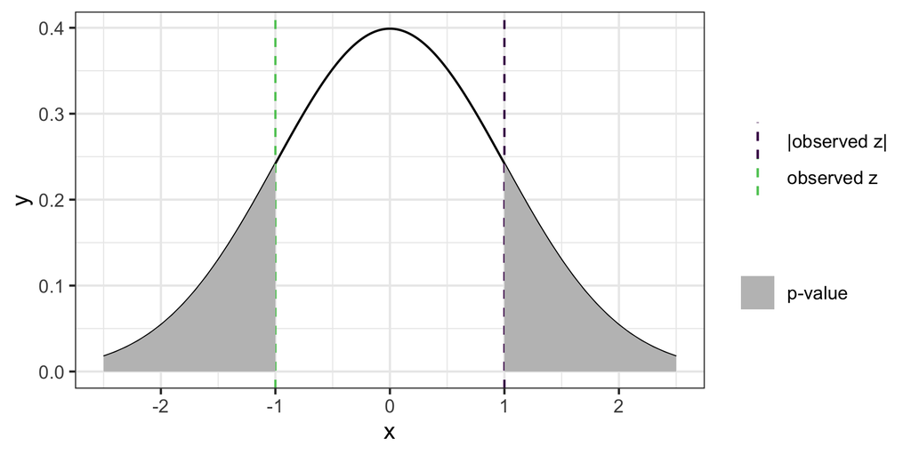

* Went through a bunch (full list [here](https://rmtrane.github.io/PUBLHLTH_783_biostats_notes/examples-of-statistical-tests.html#stat-tests-overview))

* Talked in somewhat detail about:

- t-test: for means
        * when you want to test if the mean in a group is equal to or different from a number
        * when you want to compare the means in two groups

- test for proportions:
        * test if the proportion of a population with a certain attribute (disease, for example) is equal to a number (say 0.5)
        * test if two proportions are different

* Also seen:

- `\(\chi^2\)` test
        * test if two categorical variables are related
    - test for RR

* Multiple testing problem
    - when testing many, many hypotheses at once, we are more likely to see false positives
    - Bonferroni, Benjamini-Hochberg corrections

## Take-aways from Hypothesis Testing

What you absolutely need to know:

* how to interpret a p-value
    - the probability of something more extreme **IF `\(H_0\)` IS TRUE**
    - if small, evidence against the null, so we reject
    - if large, not evidence against the null, so we do not reject
    - notes:
        * we **NEVER** accept `\(H_0\)` or `\(H_A\)`. **ALWAYS** either reject of do not reject `\(H_0\)`
        * p-value is **NOT** the probability the null/model is true. </br> Remember, loosely speaking `\(\text{p-value} = P(\text{data} | H_0)\)`, **NOT** `\(P(H_0 | \text{data})\)`.
* what test to use when
* why and when multiple testing is a problem
* how to perform the tests mentioned above in `SAS`

What I hope you have learned:

* intuition about what a statistical test is, and how it is build

# Confidence Intervals

* hypothesis test: "could this one value be the truth?"
* confidence interval: "what range of values could be the truth?"
* all the values that make the test statistic fall between the critical values:

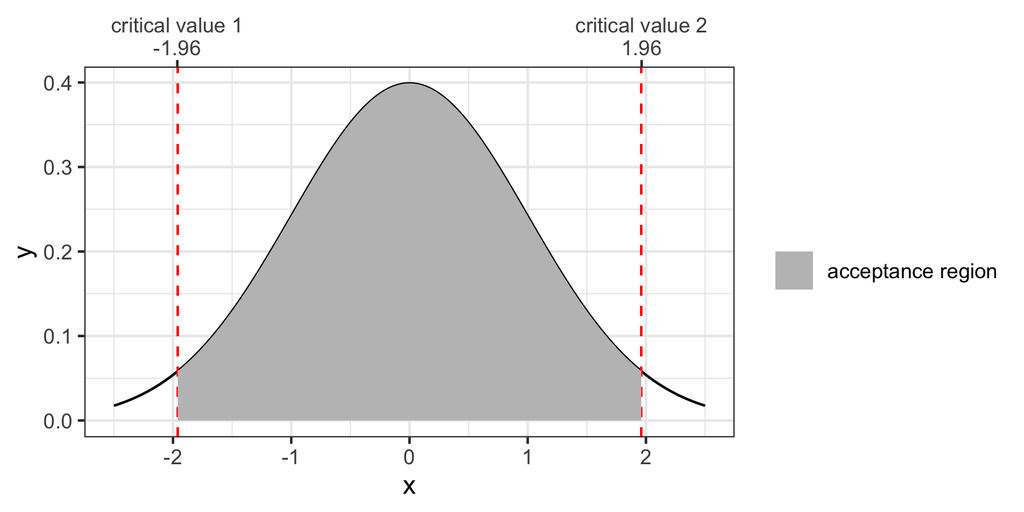

## Take-aways from Confidence Intervals

What you absolutely need to know:

* how to interpret a `\(95\%\)` confidence interval:
    - "we are `\(95\%\)` confident that the true value lies in the interval"
    - **NOT** "there's a `\(95\%\)` probability/chance the true value lies in the interval"
        * this makes it seem like the true value varies from experiment to experiment, which is **NOT** how we think about hypothesis testing/confidence intervals/life in general.
* how to compare two confidence intervals:
    - two intervals that do not overlap means there is a statistically significant difference
    - two intervals that do overlap means there is NO statistically significant difference
* how to get confidence intervals for the following quantities in `SAS`:
    - a single mean
    - difference in means
    - a single proportion
    - difference in proportions
    - RR
    - OR

* Looking for association between two continuous variables
    - find the "best straight line"
    - i.e. find `\(\beta_0, \beta_1\)` such that `\(y_i\)` is as close to `\(\beta_0 + \beta_1 \cdot x_i\)` as possible
    - interpretations:
        * if `\(\beta_1 = 0\)`, no association
        * if `\(\beta_1 < 0\)`, when `\(x\)` increases, `\(y\)` decreases
        * if `\(\beta_1 > 0\)`, when `\(x\)` increases, `\(y\)` increases

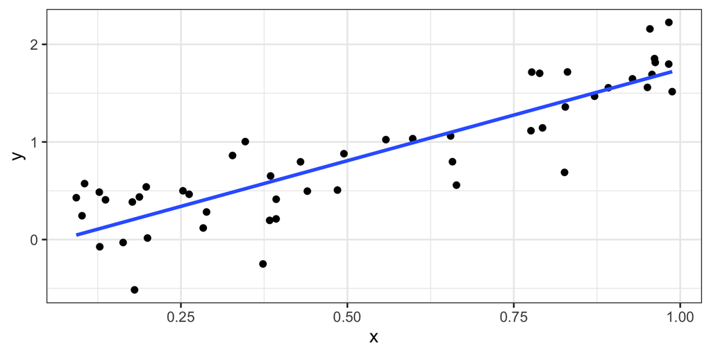

* Also allows us to adjust for other covariates:
    - find `\(\beta_0, \beta_1, \beta_2\)` such that `\(y_i\)` is as close to `\(\beta_0 + \beta_1\cdot x_{1,i} + \beta_2 \cdot x_{2,i} + \beta_3 \cdot x_{3,i}\)` as possible.
    - interpretations
        * if `\(\beta_1 = 0\)`: after accounting for everything else, no association
        * if `\(\beta_1 < 0\)`: all else being equal, when `\(x\)` increases, `\(y\)` decreases
        * if `\(\beta_1 > 0\)`: all else being equal, when `\(x\)` increases, `\(y\)` increases

## Take-aways from Linear Regression

What I hope you have learned:

* very basic intuition about linear regression
* some idea of how to interpret coefficients
* hopefully won't be scared when you encounter it in the future (cause you will)

# Tips and tricks for the final

The obvious: